```python
Dataset:Laon _ Default
Author: Poornima M
Dated: 18/10/2025

Objective: EDA to understand data structure, relationships, missing values, and outliers. Visualize key distributions and correlations.
```

```python
# ========================================
# STEP 1: Import Required Libraries
# ========================================
import pandas as pd
import numpy as np
import matplotlib.pyplot as plt
import seaborn as sns

# For better visual display
plt.style.use('ggplot')
sns.set_palette('viridis')
pd.set_option('display.max_columns', None)
```

```python
# ========================================
# STEP 2: Load Dataset
# ========================================
df = pd.read_csv("Loan_Default.csv")
print("✅ Dataset Loaded Successfully!")
```

```
✅ Dataset Loaded Successfully!
```

```python
# ========================================
# STEP 3: Initial Exploration
# ========================================
print("\n--- Basic Information ---")
print(df.info())

print("\n--- First 5 Rows ---")
print(df.head())

print("\n--- Shape of Dataset ---")
print(f"Rows: {df.shape[0]}, Columns: {df.shape[1]}")

print("\n--- Summary Statistics ---")
print(df.describe().T)
```

```
--- Basic Information ---
<class 'pandas.core.frame.DataFrame'>
RangeIndex: 148670 entries, 0 to 148669
Data columns (total 34 columns):
 #   Column                     Non-Null Count   Dtype
---  ------                     --------------   -----
 0   ID                         148670 non-null  int64
 1   year                       148670 non-null  int64
 2   loan_limit                 145326 non-null  object
 3   Gender                     148670 non-null  object
 4   approv_in_adv              147762 non-null  object
 5   loan_type                  148670 non-null  object
 6   loan_purpose               148536 non-null  object
 7   Credit_Worthiness          148670 non-null  object
 8   open_credit                148670 non-null  object
 9   business_or_commercial     148670 non-null  object
 10  loan_amount                148670 non-null  int64
 11  rate_of_interest           112231 non-null  float64
 12  Interest_rate_spread       112031 non-null  float64
 13  Upfront_charges            109028 non-null  float64
 14  term                       148629 non-null  float64
 15  Neg_ammortization          148549 non-null  object
 16  interest_only              148670 non-null  object
 17  lump_sum_payment           148670 non-null  object
 18  property_value             133572 non-null  float64
 19  construction_type          148670 non-null  object
 20  occupancy_type             148670 non-null  object
 21  Secured_by                 148670 non-null  object
 22  total_units                148670 non-null  object
 23  income                     139520 non-null  float64
 24  credit_type                148670 non-null  object
 25  Credit_Score               148670 non-null  int64
 26  co-applicant_credit_type   148670 non-null  object
 27  age                        148470 non-null  object
 28  submission_of_application  148470 non-null  object
 29  LTV                        133572 non-null  float64
 30  Region                     148670 non-null  object
 31  Security_Type              148670 non-null  object
 32  Status                     148670 non-null  int64
 33  dtir1                      124549 non-null  float64
```

[output cut: 71 more lines]

```

                               25%           50%            75%           max
ID                     62057.25000   99224.50000  136391.750000  1.735590e+05
year                    2019.00000    2019.00000    2019.000000  2.019000e+03
loan_amount           196500.00000  296500.00000  436500.000000  3.576500e+06
rate_of_interest           3.62500       3.99000       4.375000  8.000000e+00
Interest_rate_spread       0.07600       0.39040       0.775400  3.357000e+00
Upfront_charges          581.49000    2596.45000    4812.500000  6.000000e+04
term                     360.00000     360.00000     360.000000  3.600000e+02
property_value        268000.00000  418000.00000  628000.000000  1.650800e+07
income                  3720.00000    5760.00000    8520.000000  5.785800e+05
Credit_Score             599.00000     699.00000     800.000000  9.000000e+02
LTV                       60.47486      75.13587      86.184211  7.831250e+03
Status                     0.00000       0.00000       0.000000  1.000000e+00
dtir1                     31.00000      39.00000      45.000000  6.100000e+01
```

Data Completeness

- 15–25% missingness in key numeric financial fields

→ Requires imputation (median or model-based)

- Remaining data is clean and well-structured

🚨 Outliers Detected

- LTV > 100
- Extremely high property_value and loan_amount

→ Must be treated before modeling (e.g., capping, transformation)

🧠 Credit Profile

- Average credit score ≈ 700 → Moderate risk borrowers
- Default rate: 24.6%

🏦 Loan Characteristics

- Typical loan term: ~30 years
- Majority loan types: Conventional (type1, type2)

```
--- Missing Values ---
Upfront_charges              39642
Interest_rate_spread         36639
rate_of_interest             36439
dtir1                        24121
LTV                          15098
property_value               15098
income                        9150
loan_limit                    3344
approv_in_adv                  908
submission_of_application      200
age                            200
loan_purpose                   134
Neg_ammortization              121
term                            41
dtype: int64
```

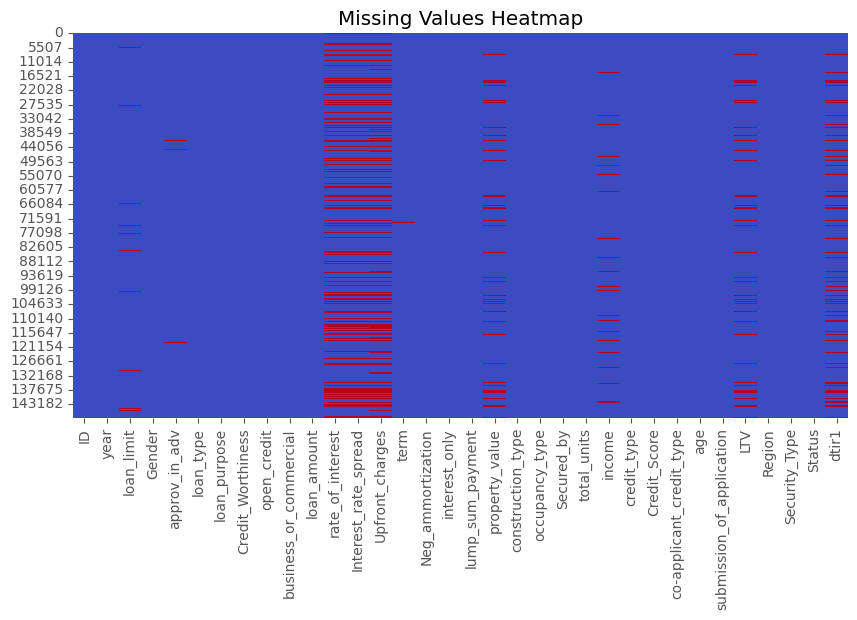

```python
# ========================================
# STEP 4: Check for Missing Values
# ========================================
print("\n--- Missing Values ---")
missing = df.isnull().sum().sort_values(ascending=False)
print(missing[missing > 0])

plt.figure(figsize=(10,5))
sns.heatmap(df.isnull(), cbar=False, cmap='coolwarm')
plt.title("Missing Values Heatmap")
plt.show()
```

Here’s a structured, assignment-ready summary of your Missing Data Analysis & Strategy, ideal for inclusion in a report or presentation:

- Columns: Upfront_charges, Interest_rate_spread, rate_of_interest
- Insight: Likely conditionally dependent (e.g., missing together for fixed-rate loans or no upfront charges)
- Strategy:
- Drop if not predictive
- Impute only if critical (e.g., median per loan type)

🟠 Moderate Missingness (10–30%)

- Columns: dtir1, LTV, property_value
- Insight: Key credit risk indicators
- Strategy:
- Impute using domain logic (e.g., median per loan type or applicant group)

🟢 Low Missingness (<10%)

- Columns: income, loan_limit, approv_in_adv, etc.
- Strategy:
- Numeric: Median or model-based imputation
- Categorical: Mode or “Unknown” category

🔗 Possible Data Relationships

- LTV & property_value: Equal missingness → may be derived features
- Action: Use missingness heatmap/matrix to detect patterns
- sns.heatmap(df.isnull(), cbar=False)
- msno.matrix(df)

```python
# ========================================
# STEP 5: Data Types & Unique Values
# ========================================
print("\n--- Data Types ---")
print(df.dtypes)

print("\n--- Unique Values Count ---")
for col in df.columns:
    print(f"{col}: {df[col].nunique()} unique values")
```

```
--- Data Types ---
ID                             int64
year                           int64
loan_limit                    object
Gender                        object
approv_in_adv                 object
loan_type                     object
loan_purpose                  object
Credit_Worthiness             object
open_credit                   object
business_or_commercial        object
loan_amount                    int64
rate_of_interest             float64
Interest_rate_spread         float64
Upfront_charges              float64
term                         float64
Neg_ammortization             object
interest_only                 object
lump_sum_payment              object
property_value               float64
construction_type             object
occupancy_type                object
Secured_by                    object
total_units                   object
income                       float64
credit_type                   object
Credit_Score                   int64
co-applicant_credit_type      object
age                           object
submission_of_application     object
LTV                          float64
Region                        object
Security_Type                 object
Status                         int64
dtir1                        float64
dtype: object

--- Unique Values Count ---
ID: 148670 unique values
year: 1 unique values
```

[output cut: 17 more lines]

```
construction_type: 2 unique values
occupancy_type: 3 unique values
Secured_by: 2 unique values
total_units: 4 unique values
income: 1001 unique values
credit_type: 4 unique values
Credit_Score: 401 unique values
co-applicant_credit_type: 2 unique values
age: 7 unique values
submission_of_application: 2 unique values
LTV: 8484 unique values
Region: 4 unique values
Security_Type: 2 unique values
Status: 2 unique values
dtir1: 57 unique values
```

Preliminary Modeling Insights 🔣 Feature Engineering Needs

- Categorical Dominance:

Dataset contains a high proportion of categorical variables → Requires encoding strategies such as:

- One-hot encoding for nominal variables
- Ordinal mapping for ranked categories
- Frequency encoding for high-cardinality features

⚠️ Class Imbalance

- Loan Default Rate: ~24.6%

→ Slight imbalance, manageable using:

- SMOTE (Synthetic Minority Over-sampling Technique)
- Class weights in model training

🔍 Key Predictors of Default

🌍 Socio-Economic Patterns

- Gender, Approval Type, and Region

→ May reveal disparities or trends in lending behavior

🏠 Property-Related Variables

- Property Value, Loan Term, Upfront Charges

→ Useful for distinguishing secured vs risky loans

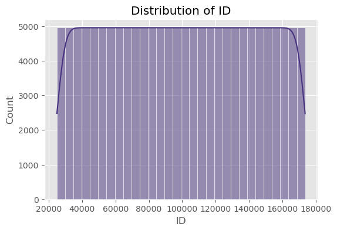

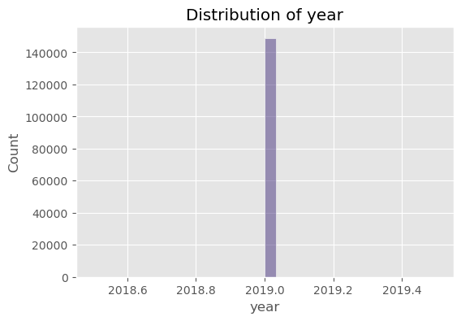

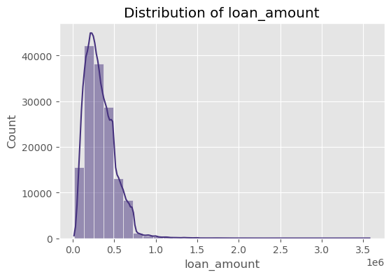

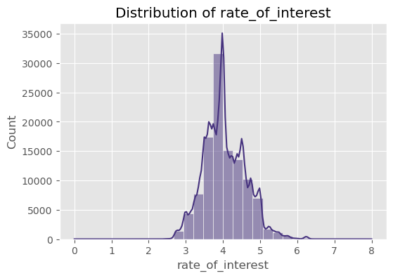

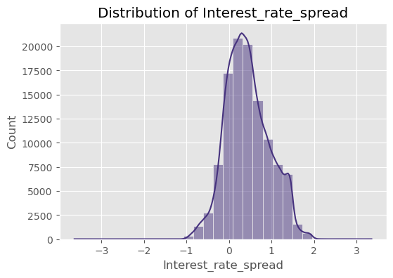

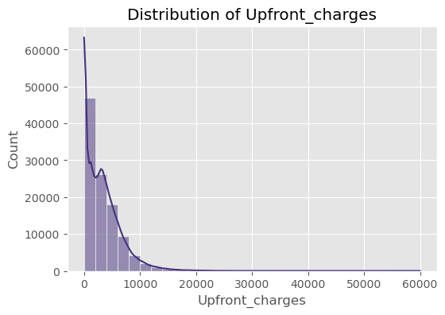

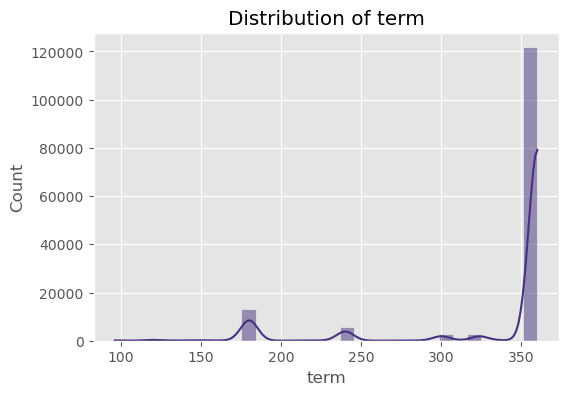

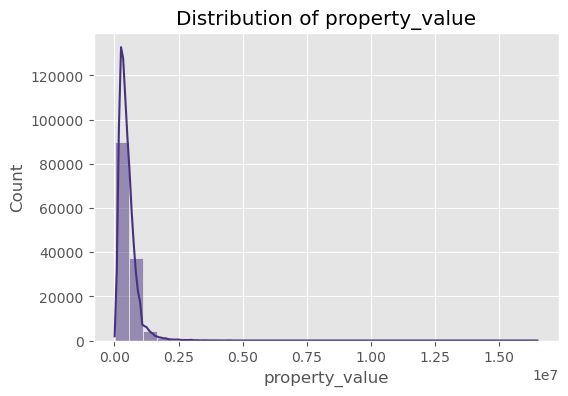

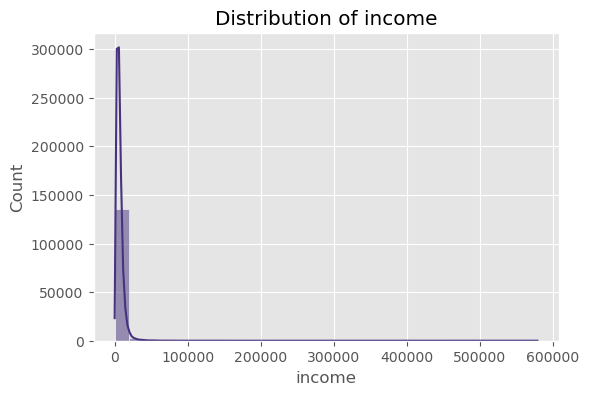

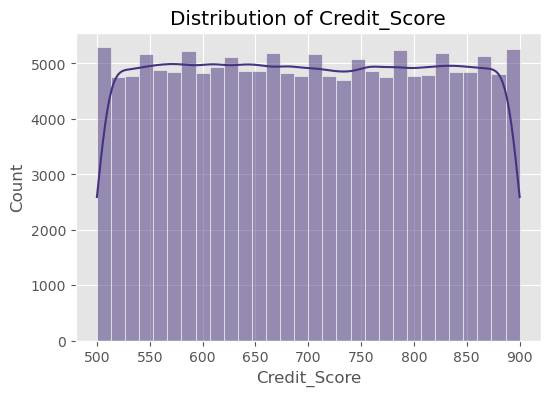

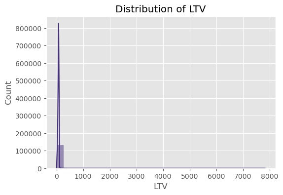

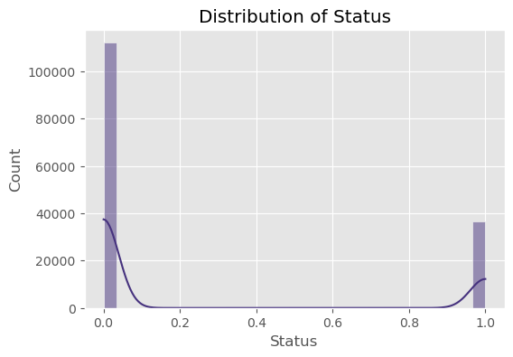

[22 more figures not shown]

```python
# ========================================
# STEP 6: Univariate Analysis
# ========================================
num_cols = df.select_dtypes(include=['int64', 'float64']).columns
cat_cols = df.select_dtypes(include=['object']).columns

# Numerical Columns
for col in num_cols:
    plt.figure(figsize=(6,4))
    sns.histplot(df[col], kde=True, bins=30)
    plt.title(f"Distribution of {col}")
    plt.show()

# Categorical Columns
for col in cat_cols:
    plt.figure(figsize=(6,4))
    sns.countplot(y=col, data=df, order=df[col].value_counts().index)
    plt.title(f"Category Distribution - {col}")
    plt.show()
```

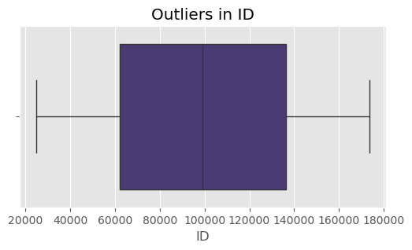

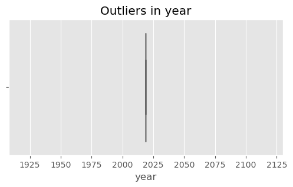

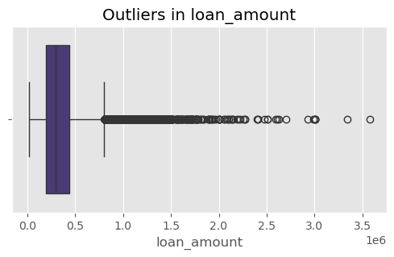

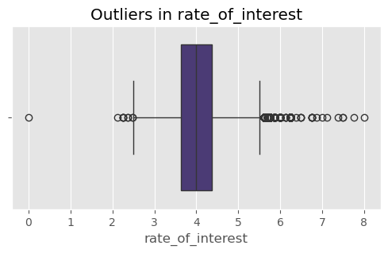

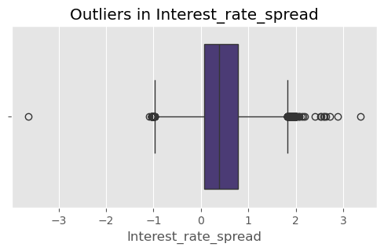

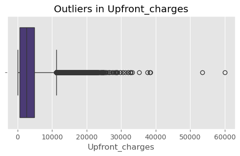

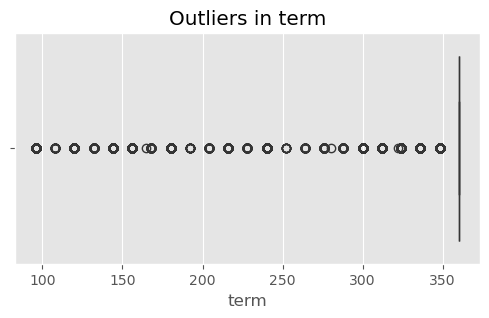

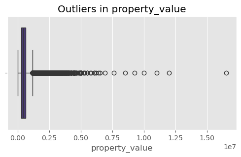

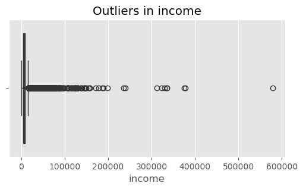

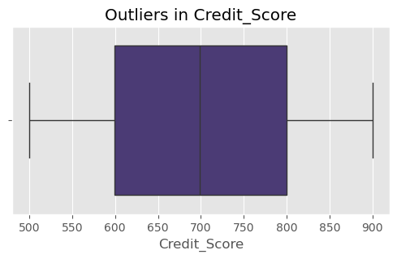

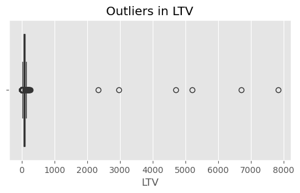

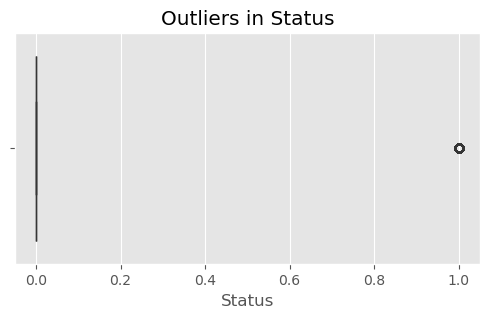

[1 more figures not shown]

```python
# ========================================
# STEP 7: Outlier Detection (Boxplots)
# ========================================
for col in num_cols:
    plt.figure(figsize=(6,3))
    sns.boxplot(x=df[col])
    plt.title(f"Outliers in {col}")
    plt.show()
```

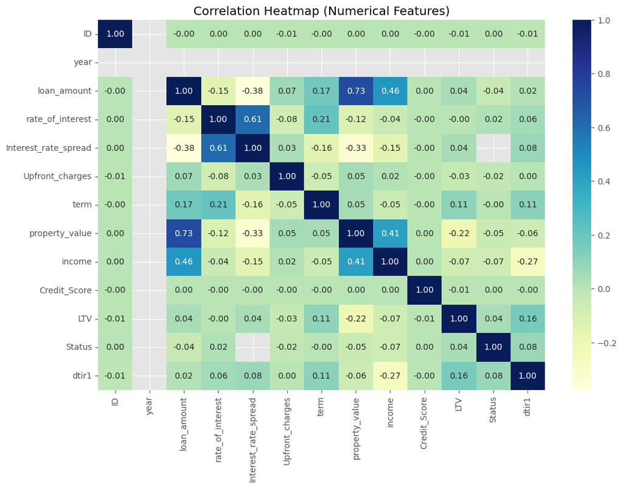

```python
# ========================================
# STEP 8: Correlation Analysis
# ========================================
plt.figure(figsize=(12,8))
corr = df[num_cols].corr()
sns.heatmap(corr, annot=True, fmt=".2f", cmap='YlGnBu')
plt.title("Correlation Heatmap (Numerical Features)")
plt.show()
```

```python
# ========================================
# STEP 9: Bivariate Analysis with Target
# ========================================
if 'loan_default' in df.columns:
    target = 'loan_default'
    for col in num_cols:
        plt.figure(figsize=(6,4))
        sns.boxplot(x=target, y=col, data=df)
        plt.title(f"{col} vs {target}")
        plt.show()

    for col in cat_cols:
        plt.figure(figsize=(6,4))
        sns.countplot(x=col, hue=target, data=df)
        plt.title(f"{col} vs {target}")
        plt.xticks(rotation=45)
        plt.show()
```

[output not shown]

```python
# ========================================
# STEP 10: Summary Insights
# ========================================
print("\n✅ EDA Completed Successfully!")
print("- Dataset shape:", df.shape)
print("- Missing values found in:", list(missing[missing>0].index))
print("- Numerical columns:", list(num_cols))
print("- Categorical columns:", list(cat_cols))
```

```
✅ EDA Completed Successfully!
- Dataset shape: (148670, 34)
- Missing values found in: ['Upfront_charges', 'Interest_rate_spread', 'rate_of_interest', 'dtir1', 'LTV', 'property_value', 'income', 'loan_limit', 'approv_in_adv', 'submission_of_application', 'age', 'loan_purpose', 'Neg_ammortization', 'term']
- Numerical columns: ['ID', 'year', 'loan_amount', 'rate_of_interest', 'Interest_rate_spread', 'Upfront_charges', 'term', 'property_value', 'income', 'Credit_Score', 'LTV', 'Status', 'dtir1']
- Categorical columns: ['loan_limit', 'Gender', 'approv_in_adv', 'loan_type', 'loan_purpose', 'Credit_Worthiness', 'open_credit', 'business_or_commercial', 'Neg_ammortization', 'interest_only', 'lump_sum_payment', 'construction_type', 'occupancy_type', 'Secured_by', 'total_units', 'credit_type', 'co…
```

```python
# ========================================
# STEP 7: EDA Summary Table
# ========================================

import pandas as pd
import numpy as np

# Create summary table
eda_summary = pd.DataFrame({
    'Data_Type': df.dtypes,
    'Missing_Values': df.isnull().sum(),
    'Missing_%': round(df.isnull().mean() * 100, 2),
    'Unique_Values': df.nunique(),
    'Min': df.select_dtypes(include=[np.number]).min(),
    'Max': df.select_dtypes(include=[np.number]).max(),
    'Mean': df.select_dtypes(include=[np.number]).mean(),
    'Std_Dev': df.select_dtypes(include=[np.number]).std()
})

# Round numeric stats for readability
eda_summary = eda_summary.round(2)

# Display neatly
print("✅ EDA Summary Table — Loan_Default Dataset")
display(eda_summary)
```

```
✅ EDA Summary Table — Loan_Default Dataset
```

|  | Data_Type | Missing_Values | Missing_% | Unique_Values | Min | Max | Mean | Std_Dev |
| --- | --- | --- | --- | --- | --- | --- | --- | --- |
| Credit_Score | int64 | 0 | 0.00 | 401 | 500.00 | 900.00 | 699.79 | 115.88 |
| Credit_Worthiness | object | 0 | 0.00 | 2 | NaN | NaN | NaN | NaN |
| Gender | object | 0 | 0.00 | 4 | NaN | NaN | NaN | NaN |
| ID | int64 | 0 | 0.00 | 148670 | 24890.00 | 173559.00 | 99224.50 | 42917.48 |
| Interest_rate_spread | float64 | 36639 | 24.64 | 22516 | -3.64 | 3.36 | 0.44 | 0.51 |
| LTV | float64 | 15098 | 10.16 | 8484 | 0.97 | 7831.25 | 72.75 | 39.97 |
| Neg_ammortization | object | 121 | 0.08 | 2 | NaN | NaN | NaN | NaN |
| Region | object | 0 | 0.00 | 4 | NaN | NaN | NaN | NaN |
| Secured_by | object | 0 | 0.00 | 2 | NaN | NaN | NaN | NaN |
| Security_Type | object | 0 | 0.00 | 2 | NaN | NaN | NaN | NaN |
| Status | int64 | 0 | 0.00 | 2 | 0.00 | 1.00 | 0.25 | 0.43 |
| Upfront_charges | float64 | 39642 | 26.66 | 58271 | 0.00 | 60000.00 | 3225.00 | 3251.12 |
| age | object | 200 | 0.13 | 7 | NaN | NaN | NaN | NaN |
| approv_in_adv | object | 908 | 0.61 | 2 | NaN | NaN | NaN | NaN |
| business_or_commercial | object | 0 | 0.00 | 2 | NaN | NaN | NaN | NaN |
| co-applicant_credit_type | object | 0 | 0.00 | 2 | NaN | NaN | NaN | NaN |
| construction_type | object | 0 | 0.00 | 2 | NaN | NaN | NaN | NaN |
| credit_type | object | 0 | 0.00 | 4 | NaN | NaN | NaN | NaN |
| dtir1 | float64 | 24121 | 16.22 | 57 | 5.00 | 61.00 | 37.73 | 10.55 |
| income | float64 | 9150 | 6.15 | 1001 | 0.00 | 578580.00 | 6957.34 | 6496.59 |
| interest_only | object | 0 | 0.00 | 2 | NaN | NaN | NaN | NaN |
| loan_amount | int64 | 0 | 0.00 | 211 | 16500.00 | 3576500.00 | 331117.74 | 183909.31 |
| loan_limit | object | 3344 | 2.25 | 2 | NaN | NaN | NaN | NaN |
| loan_purpose | object | 134 | 0.09 | 4 | NaN | NaN | NaN | NaN |
| loan_type | object | 0 | 0.00 | 3 | NaN | NaN | NaN | NaN |
| lump_sum_payment | object | 0 | 0.00 | 2 | NaN | NaN | NaN | NaN |
| occupancy_type | object | 0 | 0.00 | 3 | NaN | NaN | NaN | NaN |
| open_credit | object | 0 | 0.00 | 2 | NaN | NaN | NaN | NaN |
| property_value | float64 | 15098 | 10.16 | 385 | 8000.00 | 16508000.00 | 497893.47 | 359935.32 |
| rate_of_interest | float64 | 36439 | 24.51 | 131 | 0.00 | 8.00 | 4.05 | 0.56 |
| submission_of_application | object | 200 | 0.13 | 2 | NaN | NaN | NaN | NaN |
| term | float64 | 41 | 0.03 | 26 | 96.00 | 360.00 | 335.14 | 58.41 |
| total_units | object | 0 | 0.00 | 4 | NaN | NaN | NaN | NaN |
| year | int64 | 0 | 0.00 | 1 | 2019.00 | 2019.00 | 2019.00 | 0.00 |

🧪 Purpose of Data Diagnostics Summary 🔍 What It Provides

✅ Why It’s Useful

- Quickly Spot Missing Values

→ Enables targeted imputation or column removal

- Visualize Column Distributions

→ Helps detect skewness, modality, and transformation needs

- Identify Numeric Ranges & Outliers

→ Flags extreme values for capping or exclusion

```python
df.info()
```

```
<class 'pandas.core.frame.DataFrame'>
RangeIndex: 148670 entries, 0 to 148669
Data columns (total 34 columns):
 #   Column                     Non-Null Count   Dtype
---  ------                     --------------   -----
 0   ID                         148670 non-null  int64
 1   year                       148670 non-null  int64
 2   loan_limit                 145326 non-null  object
 3   Gender                     148670 non-null  object
 4   approv_in_adv              147762 non-null  object
 5   loan_type                  148670 non-null  object
 6   loan_purpose               148536 non-null  object
 7   Credit_Worthiness          148670 non-null  object
 8   open_credit                148670 non-null  object
 9   business_or_commercial     148670 non-null  object
```

[output cut: 26 more lines]

Dataset Overview 📦 General Info